# 📉 월마트 주간 판매액 요인 데이터 분석과 판매액 예측 모델 생성

1. team_name : **마크다운좋아용**
2. production_period : 22.03.07 ~ 22.03.12
3. team_members:
   - 김동훈 : PM / 문서화 작업 / ML - Ridge, Lasso, PolyFeatures / DL - ANN / Data Analysis / Data Preprocessing
   - 김단비 : 문서화 작업 / 발표 자료 / ML - Decision Tree / ML 알고리즘 탐색
   - 변지영 : Data Analysis/ Data Preprocessing / 전처리 기법 탐색
   - 서석정 : Data Analysis/ Data Preprocessing / 전처리 기법 탐색
   - 임낙현 : ML 알고리즘 탐색 / linear regression / 문서화 작업
4. Purpose :
   - 데이터 분석과 예측 모델 생성

## **Import Libraries**

```python
import numpy as np
import seaborn as sns
import matplotlib.pyplot as plt
import pandas as pd

from os.path import join
from os import getcwd

from datetime import datetime
from matplotlib import dates

from sklearn.preprocessing import OrdinalEncoder
from sklearn.linear_model import Lasso,LinearRegression,Ridge
from sklearn.preprocessing import PolynomialFeatures, StandardScaler
from sklearn.metrics import mean_squared_error,r2_score,accuracy_score
from sklearn.pipeline import Pipeline
from sklearn.tree import DecisionTreeRegressor
from sklearn.model_selection import train_test_split,cross_val_score
from sklearn.ensemble import RandomForestRegressor
from keras.layers import Dense
from keras.models import Sequential

from tensorflow.keras import optimizers

from xgboost import XGBRegressor
```

## **Loading Data**

```python
# set path
cur_path = getcwd()
data_path = join(cur_path,'data')
static_path = join(cur_path,'static') # path for result images

# load
df_test = pd.read_csv(join(data_path,'test.csv'))
df_train = pd.read_csv(join(data_path,'train.csv'))

# for checking dir
print('[current Absolute Path]\t{}'.format(cur_path))
print('[data folder Absolute Path]\t {}'.format(data_path))
print('[image folder Absolute Path]\t {}'.format(static_path))
```

```
[current Absolute Path]	c:\Users\kdh\Desktop\projects\project_mini_ml_team_two
[data folder Absolute Path]	 c:\Users\kdh\Desktop\projects\project_mini_ml_team_two\data
[image folder Absolute Path]	 c:\Users\kdh\Desktop\projects\project_mini_ml_team_two\static
```

```python
df_test['split'] = 'test'
df_train['split'] = 'train'
print('train shape : {}, test shape : {}'.format(df_train.shape,df_test.shape),end='\n\n')

df = pd.concat([df_test,df_train],ignore_index=True)
df
```

```
train shape : (282451, 17), test shape : (139119, 16)
```

|  | Store | Dept | Date | IsHoliday | Temperature | Fuel_Price | MarkDown1 | MarkDown2 | MarkDown3 | MarkDown4 | MarkDown5 | CPI | Unemployment | Type | Size | split | Weekly_Sales |
| --- | --- | --- | --- | --- | --- | --- | --- | --- | --- | --- | --- | --- | --- | --- | --- | --- | --- |
| 0 | 28 | 40 | 2012-01-06 | False | 50.43 | 3.599 | 5155.86 | 19549.51 | 218.29 | 636.73 | 5218.50 | 130.157516 | 12.187 | A | 206302 | test | NaN |
| 1 | 18 | 93 | 2012-03-09 | False | 38.10 | 3.876 | 7410.18 | 368.19 | 25.46 | 1852.39 | 2332.07 | 137.506690 | 8.075 | B | 120653 | test | NaN |
| 2 | 38 | 4 | 2011-05-27 | False | 76.67 | 4.087 | NaN | NaN | NaN | NaN | NaN | 129.062355 | 13.736 | C | 39690 | test | NaN |
| 3 | 29 | 33 | 2010-03-12 | False | 43.43 | 2.805 | NaN | NaN | NaN | NaN | NaN | 131.784000 | 10.064 | B | 93638 | test | NaN |
| 4 | 13 | 52 | 2010-10-29 | False | 45.12 | 2.841 | NaN | NaN | NaN | NaN | NaN | 126.436419 | 7.795 | A | 219622 | test | NaN |
| ... | ... | ... | ... | ... | ... | ... | ... | ... | ... | ... | ... | ... | ... | ... | ... | ... | ... |
| 421565 | 27 | 18 | 2012-10-19 | False | 56.53 | 4.153 | 2639.32 | NaN | 4.77 | 575.48 | 3147.23 | 142.863363 | 8.000 | A | 204184 | train | 20775.91 |
| 421566 | 39 | 36 | 2010-05-21 | False | 76.67 | 2.826 | NaN | NaN | NaN | NaN | NaN | 209.392294 | 8.464 | A | 184109 | train | 5350.00 |
| 421567 | 14 | 29 | 2010-04-30 | False | 53.15 | 2.921 | NaN | NaN | NaN | NaN | NaN | 181.662036 | 8.899 | A | 200898 | train | 10939.87 |
| 421568 | 15 | 90 | 2011-07-01 | False | 67.43 | 3.916 | NaN | NaN | NaN | NaN | NaN | 135.446800 | 7.806 | B | 123737 | train | 5013.89 |
| 421569 | 13 | 32 | 2011-10-14 | False | 51.74 | 3.567 | NaN | NaN | NaN | NaN | NaN | 129.770645 | 6.392 | A | 219622 | train | 8103.12 |

421570 rows × 17 columns

```python
df.head(3)
```

|  | Store | Dept | Date | IsHoliday | Temperature | Fuel_Price | MarkDown1 | MarkDown2 | MarkDown3 | MarkDown4 | MarkDown5 | CPI | Unemployment | Type | Size | split | Weekly_Sales |
| --- | --- | --- | --- | --- | --- | --- | --- | --- | --- | --- | --- | --- | --- | --- | --- | --- | --- |
| 0 | 28 | 40 | 2012-01-06 | False | 50.43 | 3.599 | 5155.86 | 19549.51 | 218.29 | 636.73 | 5218.50 | 130.157516 | 12.187 | A | 206302 | test | NaN |
| 1 | 18 | 93 | 2012-03-09 | False | 38.10 | 3.876 | 7410.18 | 368.19 | 25.46 | 1852.39 | 2332.07 | 137.506690 | 8.075 | B | 120653 | test | NaN |
| 2 | 38 | 4 | 2011-05-27 | False | 76.67 | 4.087 | NaN | NaN | NaN | NaN | NaN | 129.062355 | 13.736 | C | 39690 | test | NaN |

```python
df.tail(3)
```

|  | Store | Dept | Date | IsHoliday | Temperature | Fuel_Price | MarkDown1 | MarkDown2 | MarkDown3 | MarkDown4 | MarkDown5 | CPI | Unemployment | Type | Size | split | Weekly_Sales |
| --- | --- | --- | --- | --- | --- | --- | --- | --- | --- | --- | --- | --- | --- | --- | --- | --- | --- |
| 421567 | 14 | 29 | 2010-04-30 | False | 53.15 | 2.921 | NaN | NaN | NaN | NaN | NaN | 181.662036 | 8.899 | A | 200898 | train | 10939.87 |
| 421568 | 15 | 90 | 2011-07-01 | False | 67.43 | 3.916 | NaN | NaN | NaN | NaN | NaN | 135.446800 | 7.806 | B | 123737 | train | 5013.89 |
| 421569 | 13 | 32 | 2011-10-14 | False | 51.74 | 3.567 | NaN | NaN | NaN | NaN | NaN | 129.770645 | 6.392 | A | 219622 | train | 8103.12 |

```python
df.describe().T
```

|  | count | mean | std | min | 25% | 50% | 75% | max |
| --- | --- | --- | --- | --- | --- | --- | --- | --- |
| Store | 421570.0 | 22.200546 | 12.785297 | 1.000 | 11.000000 | 22.00000 | 33.000000 | 45.000000 |
| Dept | 421570.0 | 44.260317 | 30.492054 | 1.000 | 18.000000 | 37.00000 | 74.000000 | 99.000000 |
| Temperature | 421570.0 | 60.090059 | 18.447931 | -2.060 | 46.680000 | 62.09000 | 74.280000 | 100.140000 |
| Fuel_Price | 421570.0 | 3.361027 | 0.458515 | 2.472 | 2.933000 | 3.45200 | 3.738000 | 4.468000 |
| MarkDown1 | 150681.0 | 7246.420196 | 8291.221345 | 0.270 | 2240.270000 | 5347.45000 | 9210.900000 | 88646.760000 |
| MarkDown2 | 111248.0 | 3334.628621 | 9475.357325 | -265.760 | 41.600000 | 192.00000 | 1926.940000 | 104519.540000 |
| MarkDown3 | 137091.0 | 1439.421384 | 9623.078290 | -29.100 | 5.080000 | 24.60000 | 103.990000 | 141630.610000 |
| MarkDown4 | 134967.0 | 3383.168256 | 6292.384031 | 0.220 | 504.220000 | 1481.31000 | 3595.040000 | 67474.850000 |
| MarkDown5 | 151432.0 | 4628.975079 | 5962.887455 | 135.160 | 1878.440000 | 3359.45000 | 5563.800000 | 108519.280000 |
| CPI | 421570.0 | 171.201947 | 39.159276 | 126.064 | 132.022667 | 182.31878 | 212.416993 | 227.232807 |
| Unemployment | 421570.0 | 7.960289 | 1.863296 | 3.879 | 6.891000 | 7.86600 | 8.572000 | 14.313000 |
| Size | 421570.0 | 136727.915739 | 60980.583328 | 34875.000 | 93638.000000 | 140167.00000 | 202505.000000 | 219622.000000 |
| Weekly_Sales | 282451.0 | 15983.429692 | 22661.092494 | -4988.940 | 2079.330000 | 7616.55000 | 20245.745000 | 693099.360000 |

```python
df.info()
```

```
<class 'pandas.core.frame.DataFrame'>
RangeIndex: 421570 entries, 0 to 421569
Data columns (total 17 columns):
 #   Column        Non-Null Count   Dtype
---  ------        --------------   -----
 0   Store         421570 non-null  int64
 1   Dept          421570 non-null  int64
 2   Date          421570 non-null  object
 3   IsHoliday     421570 non-null  bool
 4   Temperature   421570 non-null  float64
 5   Fuel_Price    421570 non-null  float64
 6   MarkDown1     150681 non-null  float64
 7   MarkDown2     111248 non-null  float64
 8   MarkDown3     137091 non-null  float64
 9   MarkDown4     134967 non-null  float64
 10  MarkDown5     151432 non-null  float64
 11  CPI           421570 non-null  float64
 12  Unemployment  421570 non-null  float64
 13  Type          421570 non-null  object
 14  Size          421570 non-null  int64
 15  split         421570 non-null  object
 16  Weekly_Sales  282451 non-null  float64
dtypes: bool(1), float64(10), int64(3), object(3)
memory usage: 51.9+ MB
```

```python
df.isna().sum()
```

```
Store                0
Dept                 0
Date                 0
IsHoliday            0
Temperature          0
Fuel_Price           0
MarkDown1       270889
MarkDown2       310322
MarkDown3       284479
MarkDown4       286603
MarkDown5       270138
CPI                  0
Unemployment         0
Type                 0
Size                 0
split                0
Weekly_Sales    139119
dtype: int64
```

## **Data Description**

train.csv 기준으로 컬럼들에 대한 설명입니다.

[output not shown]

**TYPE** before data preprocessing

#### *Numeric*

- Store
- Dept
- Temperature
- Fuel_price
- MarkDown1~5
- CPI
- Unemployment
- Size
- Weekly_Sales

#### *Boolean*

- IsHoliday

#### *Object*

- Type
- Date

## **Pre:CORRELATION**

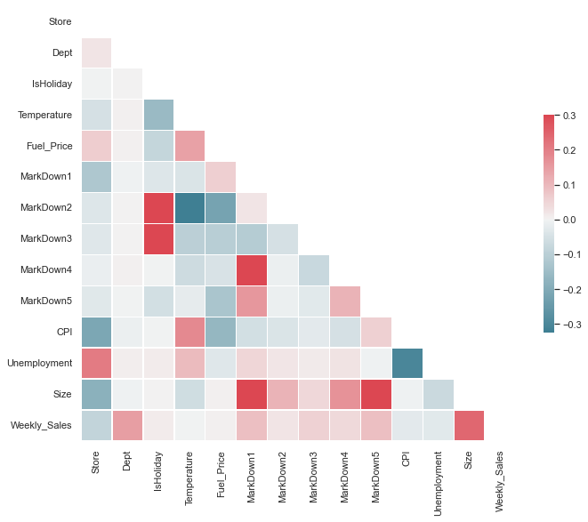

```python
corr = df.corr()
sns.set(style="white")

mask = np.zeros_like(corr, dtype=np.bool)
mask[np.triu_indices_from(mask)] = True

f, ax = plt.subplots(figsize=(11, 9))
cmap = sns.diverging_palette(220, 10, as_cmap=True)

sns.heatmap(corr, cmap=cmap, vmax=.3, center=0,mask=mask,square=True, linewidths=.5, cbar_kws={"shrink": .5})
```

## **Data Prerocessing**

```python
# p=sns.pairplot(df[df['split'] == 'train'], vars=['Weekly_Sales','Fuel_Price', 'Size', 'CPI', 'Dept', 'Temperature', 'Unemployment'])

# p = p.map_upper(sns.regplot)
# p = p.map_diag(sns.distplot)
# p = p.map_lower(sns.kdeplot)

# p.savefig('./static/pairplot.png')
```

### 1. Boolean

**IsHoliday**

```python
# check values
df[df['split']=='train']['IsHoliday'].value_counts()
```

```
False    262632
True      19819
Name: IsHoliday, dtype: int64
```

```python
# transform into int
df.loc[:,'IsHoliday'] = df['IsHoliday'].astype('category')
df['IsHoliday']
```

```
0         False
1         False
2         False
3         False
4         False
          ...
421565    False
421566    False
421567    False
421568    False
421569    False
Name: IsHoliday, Length: 421570, dtype: category
Categories (2, object): [False, True]
```

휴일

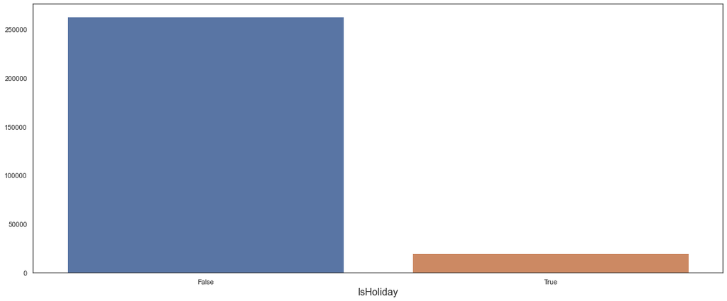

```python
fig = plt.figure(figsize=(20,8))
fig.patch.set_facecolor('white')

sns.countplot(data=df[df['split']=='train'],x='IsHoliday')

plt.xlabel('IsHoliday', fontsize=16)
plt.ylabel('')
```

휴일/비휴일 매출 분포

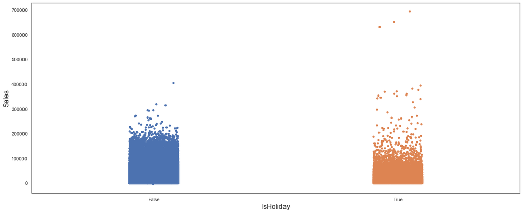

```python
fig = plt.figure(figsize=(20,8))

sns.stripplot(data = df[df['split']=='train'], y='Weekly_Sales', x='IsHoliday')

plt.ylabel('Sales', fontsize=16)
plt.xlabel('IsHoliday', fontsize=16)
```

분포로만 따졌을 때, 분명 이상치가 존재하는 것처럼 보인다.

하지만, 매출이라는 개념으로 봤을 때, 그 이상치가 실제로 잘못된 값은 아니라고 판단됀다.

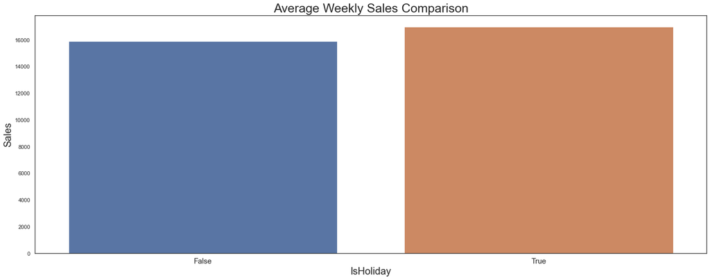

```python
fig = plt.figure(figsize=(20,8))

df_for_total_sales = df[df['split'] == 'train'][['IsHoliday','Weekly_Sales']].groupby(by='IsHoliday').mean().reset_index()

sns.barplot(data = df_for_total_sales,x='IsHoliday',y='Weekly_Sales')

plt.title('Average Weekly Sales Comparison',fontdict={'size':25})
plt.ylabel('Sales', fontsize=20)
plt.xlabel('IsHoliday', fontsize=20)
plt.xticks(fontsize=15)
plt.tight_layout()
```

휴일별 매출액

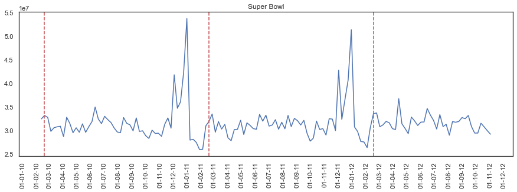

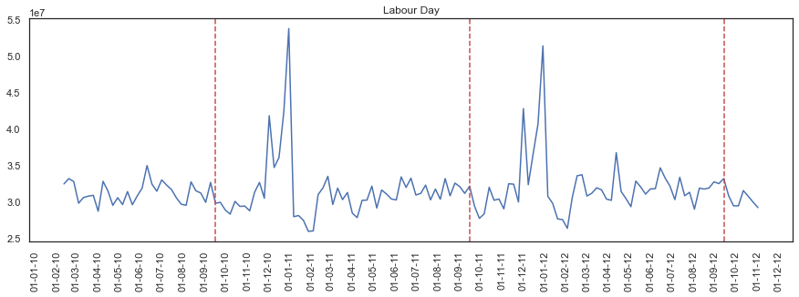

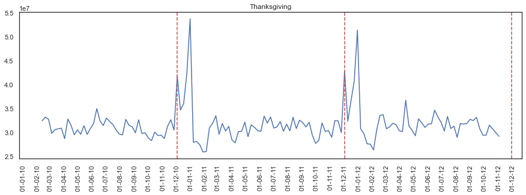

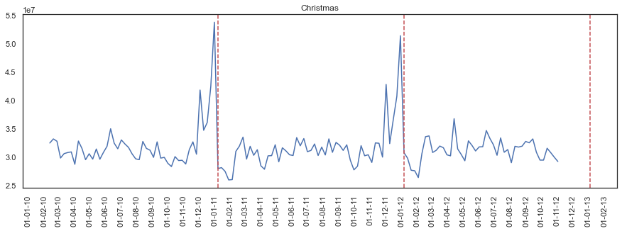

```python
df.loc[:,'Date'] = pd.to_datetime(df['Date'])

def plot_line(df,holiday_dates,holiday_label):
    fig, ax = plt.subplots(1,1,figsize = (15,5))
    ax.plot(df['Date'],df['Weekly_Sales'],label=holiday_label)

    for day in holiday_dates:
        d = datetime.strptime(day, '%d-%m-%Y')
        plt.axvline(x=d, linestyle='--', c='r')


    plt.title(holiday_label)

    xfmt = dates.DateFormatter('%d-%m-%y')

    ax.xaxis.set_major_formatter(xfmt)
    ax.xaxis.set_major_locator(dates.DayLocator(1))

    plt.gcf().autofmt_xdate(rotation=90)
    plt.show()


Super_Bowl =['12-2-2010', '11-2-2011', '10-2-2012']
Labour_Day =  ['10-9-2010', '9-9-2011', '7-9-2012']
Thanksgiving =  ['26-11-2010', '25-11-2011', '23-11-2012']
Christmas = ['31-12-2010', '30-12-2011', '28-12-2012']

total_sales = df[df['split']=='train'].groupby('Date')['Weekly_Sales'].sum().reset_index()

plot_line(total_sales,Super_Bowl,'Super Bowl')
plot_line(total_sales,Labour_Day,'Labour Day')
plot_line(total_sales,Thanksgiving,'Thanksgiving')
plot_line(total_sales,Christmas,'Christmas')
```

### 2. Object

**Date**

value check

```python
to_date = pd.to_datetime(df['Date'].copy())


print('is NA : {}'.format(to_date.isna().sum()))
print('unique value of year : {}'.format(np.sort(to_date.dt.year.unique())))
print('unique value of month : {}'.format(np.sort(to_date.dt.month.unique())))
print('unique value of day : {}'.format(np.sort(to_date.dt.day.unique())))
```

```
is NA : 0
unique value of year : [2010 2011 2012]
unique value of month : [ 1  2  3  4  5  6  7  8  9 10 11 12]
unique value of day : [ 1  2  3  4  5  6  7  8  9 10 11 12 13 14 15 16 17 18 19 20 21 22 23 24
 25 26 27 28 29 30 31]
```

날짜를 년, 월, 일, 주로 파싱

```python
df_date = pd.concat([to_date.dt.year,to_date.dt.month,to_date.dt.day,to_date.dt.isocalendar().week],axis=1,ignore_index=True)
df_date.columns = ['year','month','day','weekofyear']
df_date
```

|  | year | month | day | weekofyear |
| --- | --- | --- | --- | --- |
| 0 | 2012 | 1 | 6 | 1 |
| 1 | 2012 | 3 | 9 | 10 |
| 2 | 2011 | 5 | 27 | 21 |
| 3 | 2010 | 3 | 12 | 10 |
| 4 | 2010 | 10 | 29 | 43 |
| ... | ... | ... | ... | ... |
| 421565 | 2012 | 10 | 19 | 42 |
| 421566 | 2010 | 5 | 21 | 20 |
| 421567 | 2010 | 4 | 30 | 17 |
| 421568 | 2011 | 7 | 1 | 26 |
| 421569 | 2011 | 10 | 14 | 41 |

421570 rows × 4 columns

날짜 분포를 확인하기 위해 삼각함수를 이용한다.

```python
def encode_sin_cos(df_,col_n,max_val):
    df_[col_n+'_sin'] = np.sin(2*np.pi*df_[col_n]/max_val)
    df_[col_n+'_cos'] = np.cos(2*np.pi*df_[col_n]/max_val)

    return df_

data_sin_cos = encode_sin_cos(df_date.copy(),'month',12)
data_sin_cos = encode_sin_cos(data_sin_cos,'day',31)

data_sin_cos
```

|  | year | month | day | weekofyear | month_sin | month_cos | day_sin | day_cos |
| --- | --- | --- | --- | --- | --- | --- | --- | --- |
| 0 | 2012 | 1 | 6 | 1 | 0.500000 | 8.660254e-01 | 0.937752 | 0.347305 |
| 1 | 2012 | 3 | 9 | 10 | 1.000000 | 6.123234e-17 | 0.968077 | -0.250653 |
| 2 | 2011 | 5 | 27 | 21 | 0.500000 | -8.660254e-01 | -0.724793 | 0.688967 |
| 3 | 2010 | 3 | 12 | 10 | 1.000000 | 6.123234e-17 | 0.651372 | -0.758758 |
| 4 | 2010 | 10 | 29 | 43 | -0.866025 | 5.000000e-01 | -0.394356 | 0.918958 |
| ... | ... | ... | ... | ... | ... | ... | ... | ... |
| 421565 | 2012 | 10 | 19 | 42 | -0.866025 | 5.000000e-01 | -0.651372 | -0.758758 |
| 421566 | 2010 | 5 | 21 | 20 | 0.500000 | -8.660254e-01 | -0.897805 | -0.440394 |
| 421567 | 2010 | 4 | 30 | 17 | 0.866025 | -5.000000e-01 | -0.201299 | 0.979530 |
| 421568 | 2011 | 7 | 1 | 26 | -0.500000 | -8.660254e-01 | 0.201299 | 0.979530 |
| 421569 | 2011 | 10 | 14 | 41 | -0.866025 | 5.000000e-01 | 0.299363 | -0.954139 |

421570 rows × 8 columns

주(weekofyear)의 연속성을 확인한다.

```
weekofyear is continuous
```

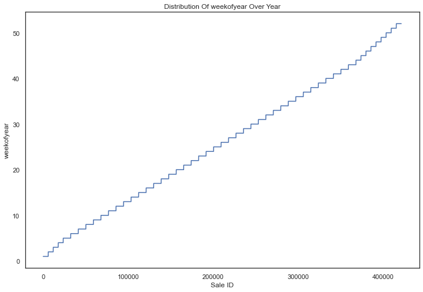

```python
subset = data_sin_cos.copy() # over all data
fig,axe = plt.subplots(1,1,facecolor='white')

m_d = subset['weekofyear'].sort_values(ignore_index=True).plot(figsize=(12,8),kind='line')

m_d.set_title("Distribution Of weekofyear Over Year")
m_d.set_ylabel("weekofyear")
m_d.set_xlabel("Sale ID")

# check by iteration
def is_continuous(lst):
    return any((pred+1 != nxt and pred!= nxt) for pred,nxt in zip(lst,lst[1:]))

print('False' if is_continuous(subset['weekofyear'].sort_values(ignore_index=True).tolist()) else 'weekofyear is continuous')
```

월(Month)의 연속성을 확인한다.

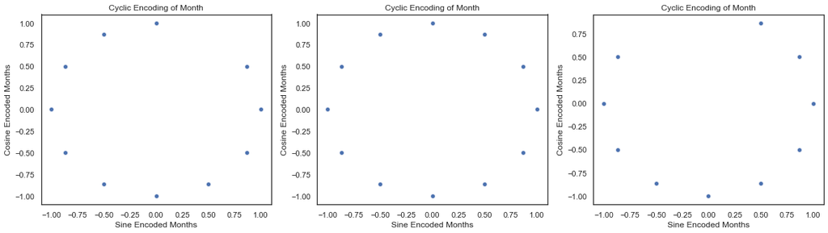

```python
fig,axe = plt.subplots(ncols=3,figsize=(20,5),facecolor='white')
year = [2010,2011,2012]
for y,i in zip(year,axe):
    c_m = sns.scatterplot(x="month_sin",y="month_cos",data=data_sin_cos[data_sin_cos['year'] == y],ax=i)

    c_m.set_title("Cyclic Encoding of Month")
    c_m.set_ylabel("Cosine Encoded Months")
    c_m.set_xlabel("Sine Encoded Months")
```

월 또한 연속적으로 존재함을 확인하였음

만든 날짜 데이터를 기존의 데이터프레임에 이어붙인다.

```python
df = pd.concat([df,data_sin_cos],axis=1)
df
```

|  | Store | Dept | Date | IsHoliday | Temperature | Fuel_Price | MarkDown1 | MarkDown2 | MarkDown3 | MarkDown4 | ... | split | Weekly_Sales | year | month | day | weekofyear | month_sin | month_cos | day_sin | day_cos |
| --- | --- | --- | --- | --- | --- | --- | --- | --- | --- | --- | --- | --- | --- | --- | --- | --- | --- | --- | --- | --- | --- |
| 0 | 28 | 40 | 2012-01-06 | False | 50.43 | 3.599 | 5155.86 | 19549.51 | 218.29 | 636.73 | ... | test | NaN | 2012 | 1 | 6 | 1 | 0.500000 | 8.660254e-01 | 0.937752 | 0.347305 |
| 1 | 18 | 93 | 2012-03-09 | False | 38.10 | 3.876 | 7410.18 | 368.19 | 25.46 | 1852.39 | ... | test | NaN | 2012 | 3 | 9 | 10 | 1.000000 | 6.123234e-17 | 0.968077 | -0.250653 |
| 2 | 38 | 4 | 2011-05-27 | False | 76.67 | 4.087 | NaN | NaN | NaN | NaN | ... | test | NaN | 2011 | 5 | 27 | 21 | 0.500000 | -8.660254e-01 | -0.724793 | 0.688967 |
| 3 | 29 | 33 | 2010-03-12 | False | 43.43 | 2.805 | NaN | NaN | NaN | NaN | ... | test | NaN | 2010 | 3 | 12 | 10 | 1.000000 | 6.123234e-17 | 0.651372 | -0.758758 |
| 4 | 13 | 52 | 2010-10-29 | False | 45.12 | 2.841 | NaN | NaN | NaN | NaN | ... | test | NaN | 2010 | 10 | 29 | 43 | -0.866025 | 5.000000e-01 | -0.394356 | 0.918958 |
| ... | ... | ... | ... | ... | ... | ... | ... | ... | ... | ... | ... | ... | ... | ... | ... | ... | ... | ... | ... | ... | ... |
| 421565 | 27 | 18 | 2012-10-19 | False | 56.53 | 4.153 | 2639.32 | NaN | 4.77 | 575.48 | ... | train | 20775.91 | 2012 | 10 | 19 | 42 | -0.866025 | 5.000000e-01 | -0.651372 | -0.758758 |
| 421566 | 39 | 36 | 2010-05-21 | False | 76.67 | 2.826 | NaN | NaN | NaN | NaN | ... | train | 5350.00 | 2010 | 5 | 21 | 20 | 0.500000 | -8.660254e-01 | -0.897805 | -0.440394 |
| 421567 | 14 | 29 | 2010-04-30 | False | 53.15 | 2.921 | NaN | NaN | NaN | NaN | ... | train | 10939.87 | 2010 | 4 | 30 | 17 | 0.866025 | -5.000000e-01 | -0.201299 | 0.979530 |
| 421568 | 15 | 90 | 2011-07-01 | False | 67.43 | 3.916 | NaN | NaN | NaN | NaN | ... | train | 5013.89 | 2011 | 7 | 1 | 26 | -0.500000 | -8.660254e-01 | 0.201299 | 0.979530 |
| 421569 | 13 | 32 | 2011-10-14 | False | 51.74 | 3.567 | NaN | NaN | NaN | NaN | ... | train | 8103.12 | 2011 | 10 | 14 | 41 | -0.866025 | 5.000000e-01 | 0.299363 | -0.954139 |

421570 rows × 25 columns

**Type**

카테고리형으로 변환

```python
df.loc[:,'Type'] = df['Type'].astype('category')
df['Type']
```

```
0         A
1         B
2         C
3         B
4         A
         ..
421565    A
421566    A
421567    A
421568    B
421569    A
Name: Type, Length: 421570, dtype: category
Categories (3, object): ['A', 'B', 'C']
```

Type 개수 분포와 주간 매출액에 따른 Type의 분포를 확인한다.

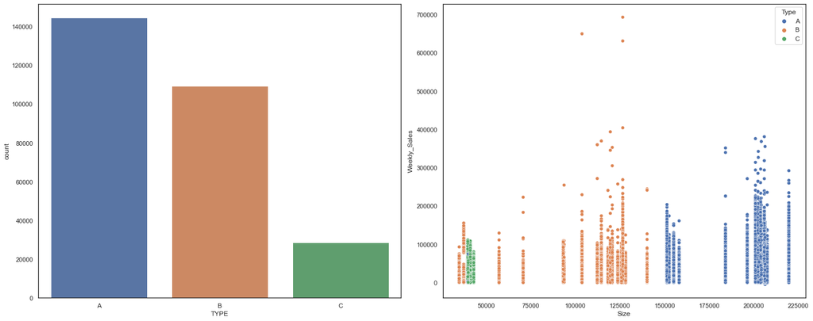

```python
fig,ax = plt.subplots(1,2,figsize=(20,8),facecolor='white')

# bar - count
sns.countplot(data=df[df['split'] == 'train'],x='Type',ax=ax[0])
ax[0].set_xlabel('TYPE')

# scatter - by type and size
sns.scatterplot(data=df[df['split'] == 'train'],x='Size', y='Weekly_Sales', hue='Type',ax=ax[1])

fig.tight_layout()
```

A 타입이 가장 많고, B 타입이 가장 큰 매출액을 차지함을 알 수 있다.

주에 따라 타입에 따른 매출액 분포를 확인한다.

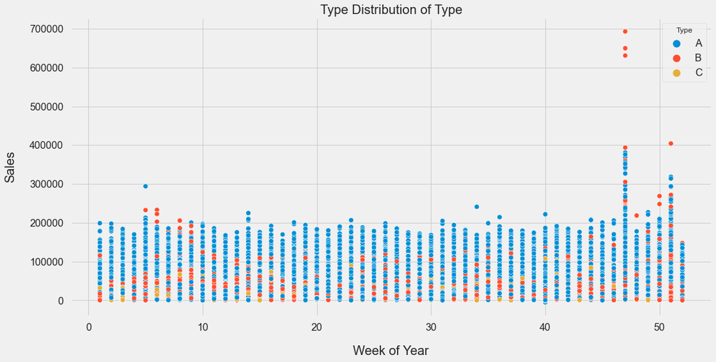

```python
plt.style.use('seaborn-poster')
plt.style.use("fivethirtyeight")

plt.figure(figsize=(16,8))

sns.scatterplot(data=df[df['split'] == 'train'],x='weekofyear', y='Weekly_Sales', hue='Type', s=60)

plt.title('Type Distribution of Type')
plt.xticks( fontsize=16)
plt.yticks( fontsize=16)

plt.xlabel('Week of Year', fontsize=20, labelpad=20)
plt.ylabel('Sales', fontsize=20, labelpad=20)
```

```python
df[df['Weekly_Sales'] == df['Weekly_Sales'].max()] # Thanksgiving Day
```

|  | Store | Dept | Date | IsHoliday | Temperature | Fuel_Price | MarkDown1 | MarkDown2 | MarkDown3 | MarkDown4 | ... | split | Weekly_Sales | year | month | day | weekofyear | month_sin | month_cos | day_sin | day_cos |
| --- | --- | --- | --- | --- | --- | --- | --- | --- | --- | --- | --- | --- | --- | --- | --- | --- | --- | --- | --- | --- | --- |
| 397772 | 10 | 72 | 2010-11-26 | True | 55.33 | 3.162 | NaN | NaN | NaN | NaN | ... | train | 693099.36 | 2010 | 11 | 26 | 47 | -0.5 | 0.866025 | -0.848644 | 0.528964 |

1 rows × 25 columns

### 3. Numeric

수치형 컬럼을 찾는다.

```python
df_numeric = df[df['split'] == 'train'].loc[:,(df.dtypes == 'float64') | (df.dtypes == 'int64')|(df.dtypes == 'int32')]
df_numeric.columns
```

```
Index(['Store', 'Dept', 'Temperature', 'Fuel_Price', 'MarkDown1', 'MarkDown2',
       'MarkDown3', 'MarkDown4', 'MarkDown5', 'CPI', 'Unemployment', 'Size',
       'Weekly_Sales', 'year', 'month', 'day', 'month_sin', 'month_cos',
       'day_sin', 'day_cos'],
      dtype='object')
```

na or null 확인

```python
df_numeric.isna().sum()
```

```
Store                0
Dept                 0
Temperature          0
Fuel_Price           0
MarkDown1       181931
MarkDown2       208219
MarkDown3       190930
MarkDown4       192420
MarkDown5       181422
CPI                  0
Unemployment         0
Size                 0
Weekly_Sales         0
year                 0
month                0
day                  0
month_sin            0
month_cos            0
day_sin              0
day_cos              0
dtype: int64
```

**Store**

```python
df_numeric['Store'].nunique()
```

```
45
```

Store와 관련한 분포를 확인한다.

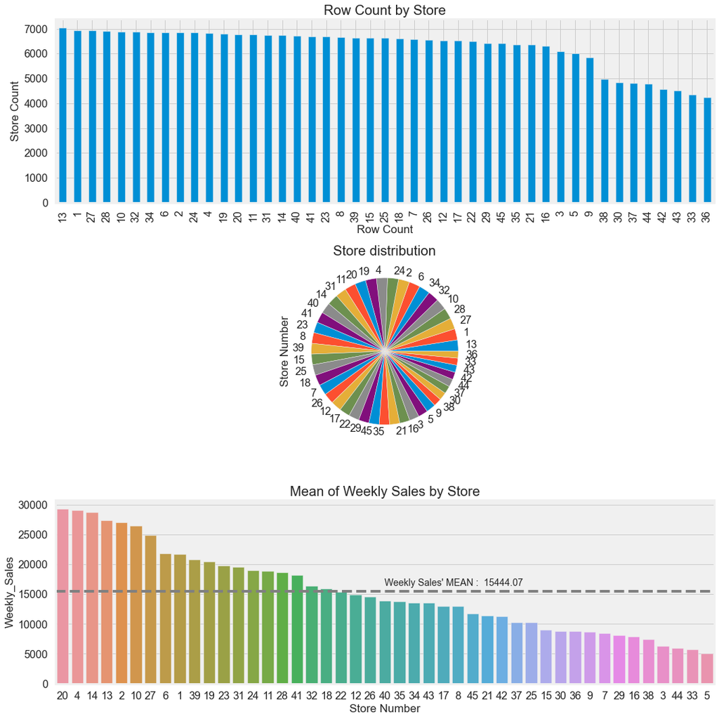

```python
# visulization

fig,ax = plt.subplots(nrows=3,ncols=1)
fig.patch.set_facecolor('white')

# Store Series
s_store = df_numeric['Store'].value_counts().sort_values(ascending=False)

# BAR plot of Store count
s_store.plot(kind='bar',ax=ax[0],title='Row Count by Store',xlabel='Row Count',ylabel='Store Count')

# PIE plot of Store distribution
s_store.plot(kind='pie',ax=ax[1],title='Store distribution',ylabel='Store Number',figsize=(15,15))

# Bar plot of Mean of Weekly Sales by Store
df_store_sale = df_numeric[['Store','Weekly_Sales']].groupby(by='Store').mean().reset_index().sort_values(by='Weekly_Sales',ascending=False,ignore_index=True)
df_store_sale.loc[:,'Store'] = df_store_sale.loc[:,'Store'].astype(str)

sns.barplot(data=df_store_sale,x='Store',y='Weekly_Sales',ax=ax[2])

# mean line
mean_v = df_store_sale['Weekly_Sales'].mean()
ax[2].axhline(y=mean_v,color='gray',linestyle='--')
ax[2].annotate("Weekly Sales' MEAN :  {}".format(round(mean_v,2)),xy=(df_store_sale['Store'].shape[0]//2,mean_v+1000))

ax[2].set_title('Mean of Weekly Sales by Store')
ax[2].set_xlabel('Store Number')


fig.tight_layout()
```

가게별 총매출

```
<class 'numpy.float64'>
```

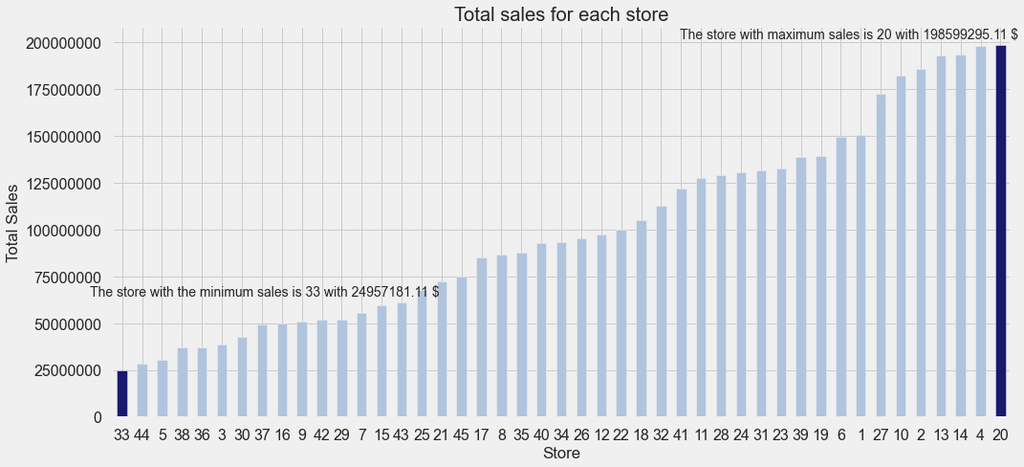

```python
plt.figure(figsize=(15,7))

total_sales_for_each_store = df[df['split']=='train'].groupby('Store')['Weekly_Sales'].sum().sort_values()
total_sales_for_each_store_array = np.array(total_sales_for_each_store) # convert to array

# Assigning a specific color for the stores with the lowest and highest sales

clrs = ['lightsteelblue' if ((x < max(total_sales_for_each_store_array)) and (x > min(total_sales_for_each_store_array))) else 'midnightblue' for x in total_sales_for_each_store_array]


ax = total_sales_for_each_store.plot(kind='bar',color=clrs);

# Store with minimum sales

p = ax.patches[0]
print(type(p.get_height()))
ax.annotate("The store with the minimum sales is 33 with {0:.2f} $".format((p.get_height())), xy=(p.get_x(), p.get_height()), xycoords='data',
            xytext=(0.17, 0.32), textcoords='axes fraction',
            arrowprops=dict(arrowstyle="->", connectionstyle="arc3"),
            horizontalalignment='center', verticalalignment='center')


# Store with maximum sales

p = ax.patches[44]
ax.annotate("The store with maximum sales is 20 with {0:.2f} $".format((p.get_height())), xy=(p.get_x(), p.get_height()), xycoords='data',
            xytext=(0.82, 0.98), textcoords='axes fraction',
            arrowprops=dict(arrowstyle="->", connectionstyle="arc3"),
            horizontalalignment='center', verticalalignment='center')


# Plot properties

plt.xticks(rotation=0)
plt.ticklabel_format(useOffset=False, style='plain', axis='y')
plt.title('Total sales for each store')
plt.xlabel('Store')
plt.ylabel('Total Sales');
```

1. Dept

```python
df.loc[:,'Dept'] = df.loc[:,'Dept'].astype('category')
df_numeric['Dept'].nunique()
```

```
81
```

```python
s_dept = df_numeric[['Dept','Weekly_Sales']]
s_dept
```

|  | Dept | Weekly_Sales |
| --- | --- | --- |
| 139119 | 92 | 87235.57 |
| 139120 | 22 | 5945.97 |
| 139121 | 28 | 1219.89 |
| 139122 | 9 | 11972.71 |
| 139123 | 55 | 8271.82 |
| ... | ... | ... |
| 421565 | 18 | 20775.91 |
| 421566 | 36 | 5350.00 |
| 421567 | 29 | 10939.87 |
| 421568 | 90 | 5013.89 |
| 421569 | 32 | 8103.12 |

282451 rows × 2 columns

부서별 평균매출

```
<class 'numpy.float64'>
```

[figure not shown]

```python
plt.figure(figsize=(20,8))

total_sales_for_each_dept = df[df['split']=='train'].groupby('Dept')['Weekly_Sales'].mean().sort_values()
total_sales_for_each_dept_array = np.array(total_sales_for_each_dept) # convert to array

# Assigning a specific color for the stores with the lowest and highest sales

clrs = ['lightsteelblue' if ((x < max(total_sales_for_each_dept_array)) and (x > min(total_sales_for_each_dept_array))) else 'midnightblue' for x in total_sales_for_each_dept_array]


ax = total_sales_for_each_dept.plot(kind='bar',color=clrs)

# Store with minimum sales

p = ax.patches[0]
print(type(p.get_height()))
ax.annotate("The dept with the minimum sales is 33 with {0:.2f} $".format((p.get_height())), xy=(p.get_x(), p.get_height()), xycoords='data',
            xytext=(0.17, 0.32), textcoords='axes fraction',
            arrowprops=dict(arrowstyle="->", connectionstyle="arc3"),
            horizontalalignment='center', verticalalignment='center')


# Store with maximum sales

p = ax.patches[44]
ax.annotate("The dept with maximum sales is 20 with {0:.2f} $".format((p.get_height())), xy=(p.get_x(), p.get_height()), xycoords='data',
            xytext=(0.82, 0.98), textcoords='axes fraction',
            arrowprops=dict(arrowstyle="->", connectionstyle="arc3"),
            horizontalalignment='center', verticalalignment='center')


# Plot properties

plt.xticks(rotation=90)
plt.ticklabel_format(useOffset=False, style='plain', axis='y')
plt.title('Average sales for each dept')
plt.xlabel('Dept')
plt.ylabel('Average saless');
```

department distribution in top 5 store for average weekly sales

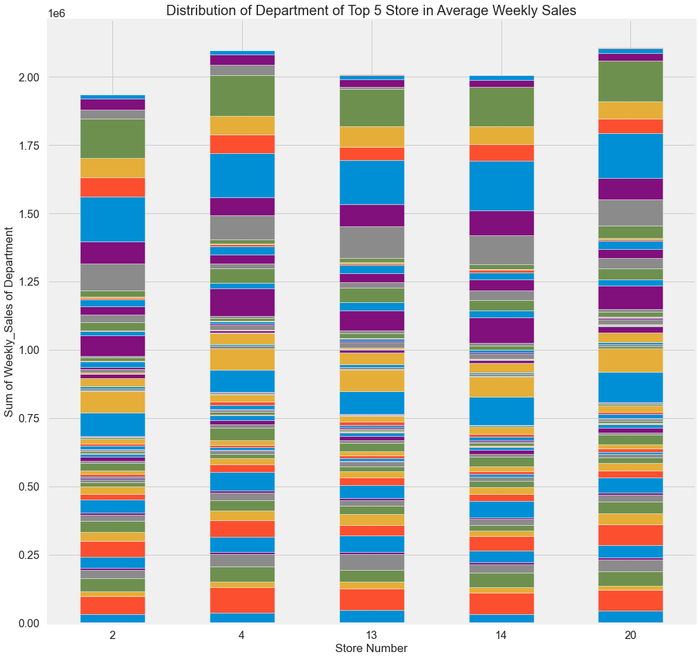

```python
top_5_store = df_store_sale.head(5)['Store'].tolist()
df_s_d_pivot = df_numeric[df_numeric['Store'].isin(top_5_store)][['Store','Dept','Weekly_Sales']].groupby(['Store','Dept']).mean().reset_index().pivot(columns='Dept',index='Store')

fig,ax = plt.subplots(1,1,figsize=(15,15))
fig.set_facecolor('white')

df_s_d_pivot.plot(kind='bar',stacked=True,legend=False,rot=0,
                  title='Distribution of Department of Top 5 Store in Average Weekly Sales',
                  ax=ax,
                  xlabel='Store Number',
                  ylabel='Sum of Weekly_Sales of Department')
```

- 평균 주간 매출액이 가장 많은 5개 점포에서의 부서 분포는 대부분 비슷했다.

**Temperature**

화씨를 섭씨로 변환한다.

```python
df.loc[:,'Temperature'] = (df['Temperature'] - 32) * 5/9
df['Temperature']
```

```
0         10.238889
1          3.388889
2         24.816667
3          6.350000
4          7.288889
            ...
421565    13.627778
421566    24.816667
421567    11.750000
421568    19.683333
421569    10.966667
Name: Temperature, Length: 421570, dtype: float64
```

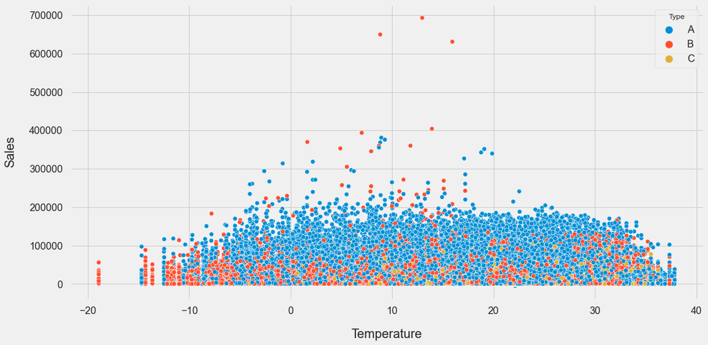

```python
plt.figure(figsize=(16,8))
sns.scatterplot(data=df[df['split'] == 'train'],x='Temperature', y='Weekly_Sales', hue='Type', s=50)

plt.xticks( fontsize=16)
plt.yticks( fontsize=16)

plt.xlabel('Temperature', fontsize=20, labelpad=20)
plt.ylabel('Sales', fontsize=20, labelpad=20)
```

**Fuel**

```python
df['Fuel_Price'].describe()
```

```
count    421570.000000
mean          3.361027
std           0.458515
min           2.472000
25%           2.933000
50%           3.452000
75%           3.738000
max           4.468000
Name: Fuel_Price, dtype: float64
```

```python
# pandas의 cut과 qcut을 이용해 수치형 데이터를 범주형 데이터로 변형시킵니다.
bins = [2.25, 2.5, 2.75, 3, 3.25, 3.5, 3.75, 4, 4.25, 4.5]
ctg = pd.cut(df['Fuel_Price'], bins=bins)

# 구간별로 값이 몇 개가 속해 있는지 value_counts()로 확인
ctg.value_counts().sort_index()
```

```
(2.25, 2.5]        38
(2.5, 2.75]     51751
(2.75, 3.0]     70800
(3.0, 3.25]     48840
(3.25, 3.5]     50478
(3.5, 3.75]    100962
(3.75, 4.0]     72126
(4.0, 4.25]     23334
(4.25, 4.5]      3241
Name: Fuel_Price, dtype: int64
```

연료 가격 분포를 확인한다.

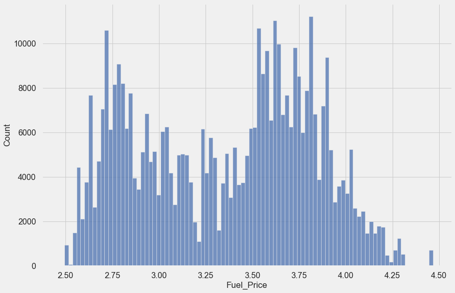

```python
sns.histplot(df['Fuel_Price'])
```

주간 매출액에 대한 연료 가격의 분포를 확인한다.

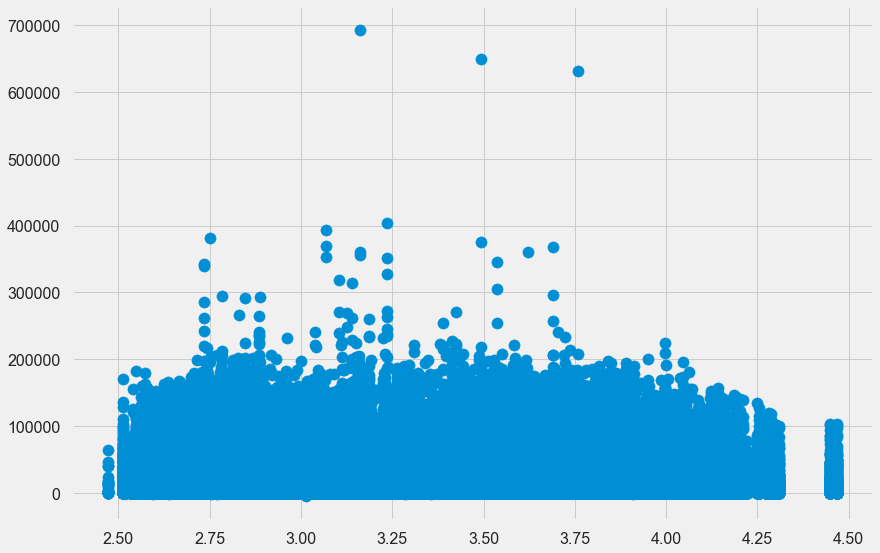

```python
plt.scatter(df['Fuel_Price'],df['Weekly_Sales'])
```

타입과 매출액에 따른 연료 가격 분포를 확인한다.

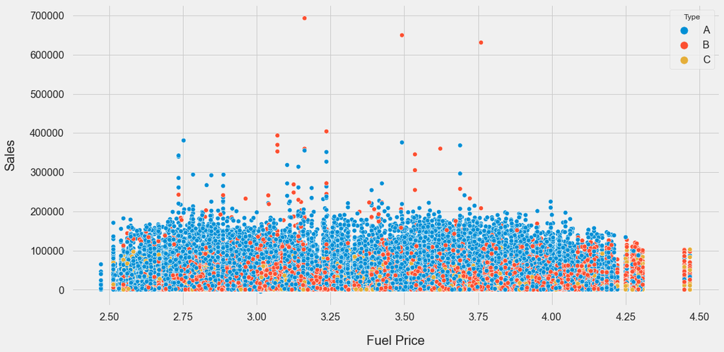

```python
plt.figure(figsize=(16,8))
sns.scatterplot(data=df,x='Fuel_Price', y='Weekly_Sales', hue='Type', s=50)

plt.xticks( fontsize=16)
plt.yticks( fontsize=16)

plt.xlabel('Fuel Price', fontsize=20, labelpad=20)
plt.ylabel('Sales', fontsize=20, labelpad=20)
```

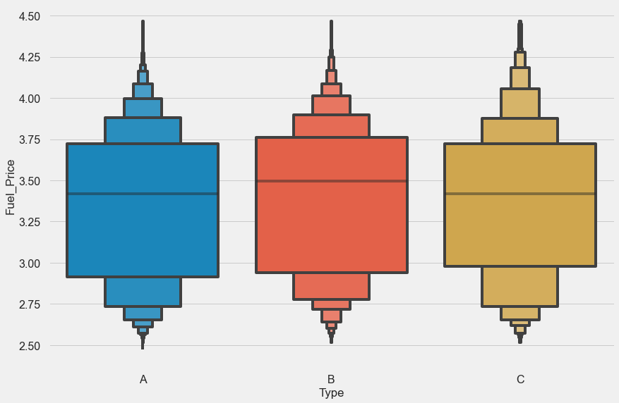

```python
sns.boxenplot(data=df,x='Type',y='Fuel_Price')
```

이상치가 보이지는 않는다.

**unemployment**

실업률의 분포를 확인한다.

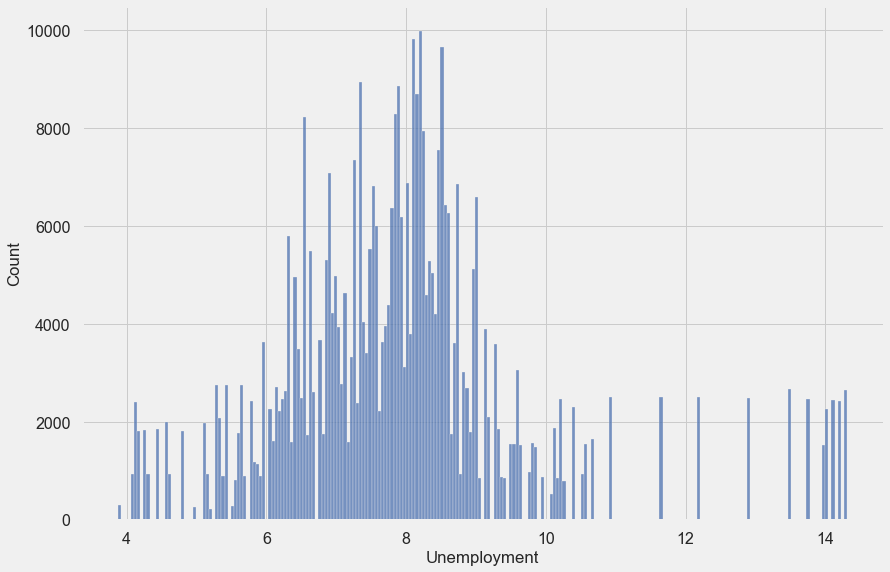

```python
sns.histplot(df['Unemployment'])
```

실업률의 분포를 매출액과 타입에 따라 확인한다.

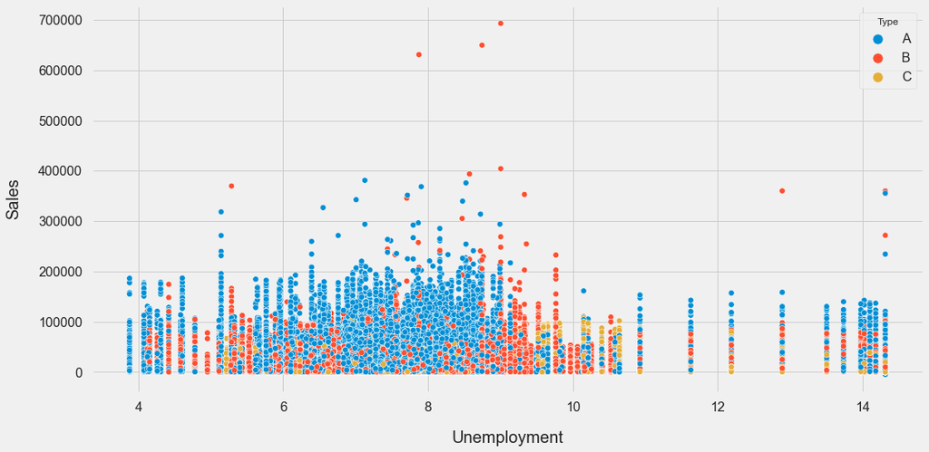

```python
plt.figure(figsize=(16,8))
sns.scatterplot(x=df['Unemployment'], y=df['Weekly_Sales'], hue=df['Type'], s=50)

plt.xticks( fontsize=16)
plt.yticks( fontsize=16)
plt.xlabel('Unemployment', fontsize=20, labelpad=20)
plt.ylabel('Sales', fontsize=20, labelpad=20)
```

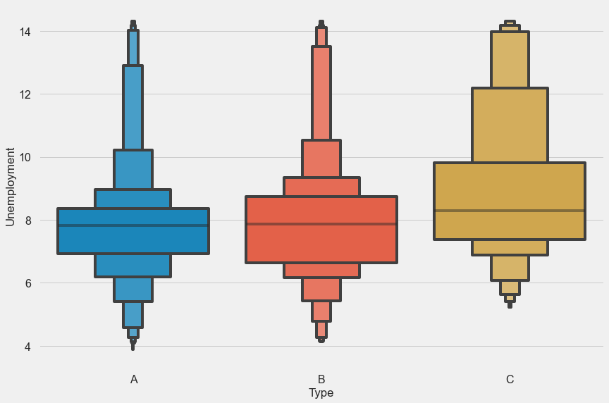

```python
sns.boxenplot(data=df,x='Type',y='Unemployment')
```

마찬가지로 이상치는 보이지 않는다.

**Size**

크기에 따른 매출액 분포를 확인한다.

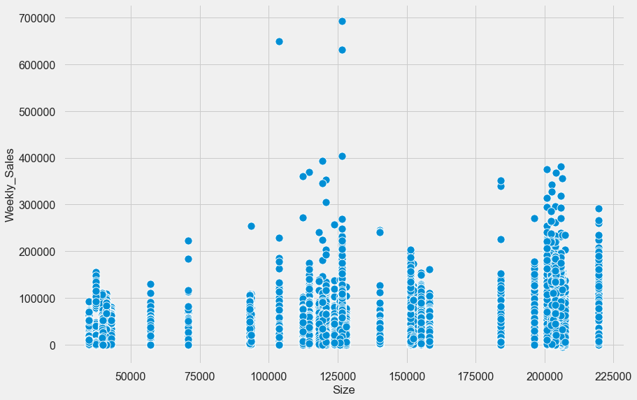

```python
sns.scatterplot(df['Size'],df['Weekly_Sales'])
```

```python
bins = [0, 50000, 100000,150000, 200000,250000]
ctg = pd.cut(df['Size'], bins=bins)
ctg.value_counts().sort_index()
```

```
(0, 50000]           73341
(50000, 100000]      38524
(100000, 150000]    106936
(150000, 200000]     70200
(200000, 250000]    132569
Name: Size, dtype: int64
```

```python
conditionlist = [
    (df['Size'] <= 50000) ,
    (df['Size'] >= 50000) & (df['Size'] <=100000),
    (df['Size'] >= 100000) & (df['Size'] <=150000),
    (df['Size'] >= 150000) & (df['Size'] <=200000),
    (df['Size'] <= 250000)]
choicelist = ['S', 'SM', 'M','ML','L']
df['Size_category'] = np.select(conditionlist, choicelist, default='Not Specified')

df.loc[:,'Size_category'] = df['Size_category'].astype('category')
df[['Size','Size_category']]
```

|  | Size | Size_category |
| --- | --- | --- |
| 0 | 206302 | L |
| 1 | 120653 | M |
| 2 | 39690 | S |
| 3 | 93638 | SM |
| 4 | 219622 | L |
| ... | ... | ... |
| 421565 | 204184 | L |
| 421566 | 184109 | ML |
| 421567 | 200898 | L |
| 421568 | 123737 | M |
| 421569 | 219622 | L |

421570 rows × 2 columns

매장 사이즈별 개수를 확인한다.

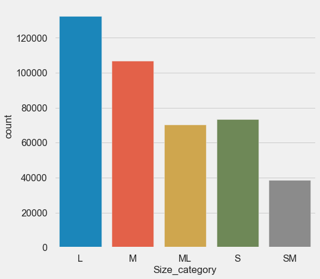

```python
fig,ax = plt.subplots(1,1,figsize=(7,7))
sns.countplot(data=df,x='Size_category',ax=ax)
ax.set_xlabel('Size_category')
```

매장 사이즈별 주간 매출액을 살펴본다.

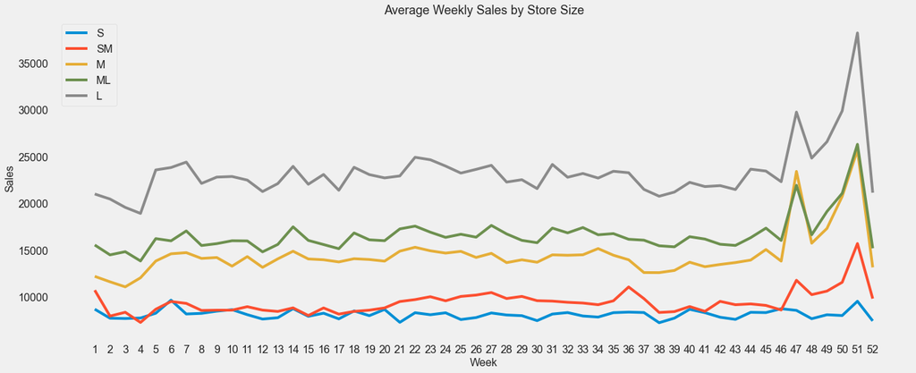

```python
#매장 사이즈별 매출 평균
wksale_by_sizeS = df[df['Size_category']=='S']['Weekly_Sales'].groupby(df['weekofyear']).mean()
wksale_by_sizeSM = df[df['Size_category']=='SM']['Weekly_Sales'].groupby(df['weekofyear']).mean()
wksale_by_sizeM = df[df['Size_category']=='M']['Weekly_Sales'].groupby(df['weekofyear']).mean()
wksale_by_sizeML = df[df['Size_category']=='ML']['Weekly_Sales'].groupby(df['weekofyear']).mean()
wksale_by_sizeL = df[df['Size_category']=='L']['Weekly_Sales'].groupby(df['weekofyear']).mean()

# 매장 사이즈별 매출 => ML 사이즈의 매장이 S,M 사이즈의 매장보다 수가 적지만 매출액은 높음 => 가게가 클수록 매출액이 높다.
plt.figure(figsize=(20,8))
sns.lineplot(wksale_by_sizeS.index,wksale_by_sizeS.values)
sns.lineplot(wksale_by_sizeSM.index,wksale_by_sizeSM.values)
sns.lineplot(wksale_by_sizeM.index,wksale_by_sizeM.values)
sns.lineplot(wksale_by_sizeML.index,wksale_by_sizeML.values)
sns.lineplot(wksale_by_sizeL.index,wksale_by_sizeL.values)

plt.grid()
plt.xticks(np.arange(1, 53, step=1))
plt.legend(['S','SM','M','ML','L'], loc='best', fontsize=16)
plt.title('Average Weekly Sales by Store Size', fontsize=18)
plt.ylabel('Sales', fontsize=16)
plt.xlabel('Week', fontsize=16)
plt.show()
```

- 크기가 클수록 매출액이 더 큰 것을 알 수 있었다.

타입에 따른 크기(bin) 분포를 확인한다.

[figure not shown]

```python
fig,ax= plt.subplots(1,3,figsize=(20,8))

sns.countplot(data=df[df['Type']==0],x='Size_category',ax=ax[0])
sns.countplot(data=df[df['Type']==1],x='Size_category',ax=ax[1])
sns.countplot(data=df[df['Type']==2],x='Size_category',ax=ax[2])

ax[0].set_xlabel('Type A')
ax[1].set_xlabel('Type B')
ax[2].set_xlabel('Type C')
```

결론적으로, 주간 매출액과의 관계가 높음

**CPI**

CPI 지수를 기준으로 매출액과 타입에 따른 분포를 확인한다.

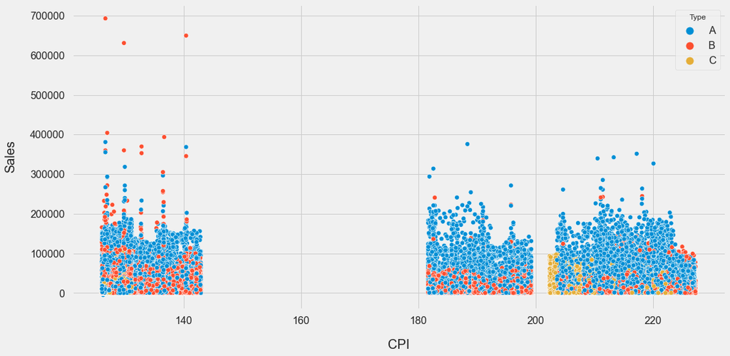

```python
plt.figure(figsize=(16,8))

sns.scatterplot(data=df,x='CPI', y='Weekly_Sales', hue='Type', s=50)

plt.xticks(fontsize=16)
plt.yticks(fontsize=16)
plt.xlabel('CPI', fontsize=20, labelpad=20)
plt.ylabel('Sales', fontsize=20, labelpad=20)
```

## **After:CORRELATION**

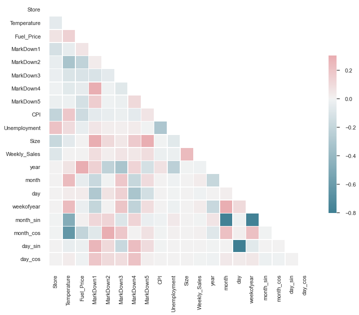

```python
corr = df.corr()

sns.set(style="white")

mask = np.zeros_like(corr, dtype=np.bool)
mask[np.triu_indices_from(mask)] = True

f, ax = plt.subplots(figsize=(11, 9))
cmap = sns.diverging_palette(220, 10, as_cmap=True)

sns.heatmap(corr, cmap=cmap, vmax=.3, center=0,mask=mask,
            square=True, linewidths=.5, cbar_kws={"shrink": .6})
```

```python
corr_cols = corr.loc[corr.columns.difference(['Weekly_Sales']),'Weekly_Sales'].abs().sort_values(ascending=False)
print(corr_cols)
```

```
Size            0.243935
MarkDown1       0.089862
MarkDown5       0.089408
Store           0.084795
MarkDown3       0.056325
MarkDown4       0.045958
month           0.028490
weekofyear      0.027710
Unemployment    0.025850
MarkDown2       0.023672
CPI             0.022459
month_cos       0.010222
year            0.008247
day             0.007012
day_cos         0.003231
month_sin       0.002990
Fuel_Price      0.002720
day_sin         0.001819
Temperature     0.001079
Name: Weekly_Sales, dtype: float64
```

## **Data Preprocessing**

```python
df.info()
```

```
<class 'pandas.core.frame.DataFrame'>
RangeIndex: 421570 entries, 0 to 421569
Data columns (total 26 columns):
 #   Column         Non-Null Count   Dtype
---  ------         --------------   -----
 0   Store          421570 non-null  int64
 1   Dept           421570 non-null  category
 2   Date           421570 non-null  datetime64[ns]
 3   IsHoliday      421570 non-null  category
 4   Temperature    421570 non-null  float64
 5   Fuel_Price     421570 non-null  float64
 6   MarkDown1      150681 non-null  float64
 7   MarkDown2      111248 non-null  float64
 8   MarkDown3      137091 non-null  float64
 9   MarkDown4      134967 non-null  float64
```

[output cut: 18 more lines]

```python
df.head()
```

|  | Store | Dept | Date | IsHoliday | Temperature | Fuel_Price | MarkDown1 | MarkDown2 | MarkDown3 | MarkDown4 | ... | Weekly_Sales | year | month | day | weekofyear | month_sin | month_cos | day_sin | day_cos | Size_category |
| --- | --- | --- | --- | --- | --- | --- | --- | --- | --- | --- | --- | --- | --- | --- | --- | --- | --- | --- | --- | --- | --- |
| 0 | 28 | 40 | 2012-01-06 | False | 10.238889 | 3.599 | 5155.86 | 19549.51 | 218.29 | 636.73 | ... | NaN | 2012 | 1 | 6 | 1 | 0.500000 | 8.660254e-01 | 0.937752 | 0.347305 | L |
| 1 | 18 | 93 | 2012-03-09 | False | 3.388889 | 3.876 | 7410.18 | 368.19 | 25.46 | 1852.39 | ... | NaN | 2012 | 3 | 9 | 10 | 1.000000 | 6.123234e-17 | 0.968077 | -0.250653 | M |
| 2 | 38 | 4 | 2011-05-27 | False | 24.816667 | 4.087 | NaN | NaN | NaN | NaN | ... | NaN | 2011 | 5 | 27 | 21 | 0.500000 | -8.660254e-01 | -0.724793 | 0.688967 | S |
| 3 | 29 | 33 | 2010-03-12 | False | 6.350000 | 2.805 | NaN | NaN | NaN | NaN | ... | NaN | 2010 | 3 | 12 | 10 | 1.000000 | 6.123234e-17 | 0.651372 | -0.758758 | SM |
| 4 | 13 | 52 | 2010-10-29 | False | 7.288889 | 2.841 | NaN | NaN | NaN | NaN | ... | NaN | 2010 | 10 | 29 | 43 | -0.866025 | 5.000000e-01 | -0.394356 | 0.918958 | L |

5 rows × 26 columns

수정해야할 컬럼 : Dept, Date, IsHoliday, Type, split, Size_category, weekofyear

```python
# Dept
df.loc[:,'Dept'] = df['Dept'].astype('int')

# Date 컬럼은 데이터 준비단계에서 따로 제외시킨다.

# IsHoliday
df.loc[:,'IsHoliday'] = df['IsHoliday'].astype('int64')

# weekofyear
df.loc[:,'weekofyear'] = df['weekofyear'].astype('int64')

# Type
ordinal_ecd = OrdinalEncoder(dtype='int')
df.loc[:,'Type'] = ordinal_ecd.fit_transform(df['Type'].to_numpy().reshape(-1,1))


# Size_category
df.loc[:,'Size_category'] = ordinal_ecd.fit_transform(df['Size_category'].to_numpy().reshape(-1,1))

# markdown
df.drop(['MarkDown1','MarkDown2','MarkDown3','MarkDown4','MarkDown5'],axis=1,inplace=True)
```

data preparation

```python
train = df[df['split'] == 'train'].loc[:,df.columns.difference(['split'])]
test = df[df['split'] == 'test'].loc[:,df.columns.difference(['split'])]

X = train.loc[:,train.columns.difference(['Date','Weekly_Sales'])]
y = train.loc[:,'Weekly_Sales']
```

```python
X.info()
```

```
<class 'pandas.core.frame.DataFrame'>
Int64Index: 282451 entries, 139119 to 421569
Data columns (total 18 columns):
 #   Column         Non-Null Count   Dtype
---  ------         --------------   -----
 0   CPI            282451 non-null  float64
 1   Dept           282451 non-null  int32
 2   Fuel_Price     282451 non-null  float64
 3   IsHoliday      282451 non-null  int64
 4   Size           282451 non-null  int64
 5   Size_category  282451 non-null  int64
 6   Store          282451 non-null  int64
 7   Temperature    282451 non-null  float64
 8   Type           282451 non-null  int64
 9   Unemployment   282451 non-null  float64
 10  day            282451 non-null  int64
 11  day_cos        282451 non-null  float64
 12  day_sin        282451 non-null  float64
 13  month          282451 non-null  int64
 14  month_cos      282451 non-null  float64
 15  month_sin      282451 non-null  float64
 16  weekofyear     282451 non-null  int64
 17  year           282451 non-null  int64
dtypes: float64(8), int32(1), int64(9)
memory usage: 39.9 MB
```

## **Modeling**

```python
X_train, X_test, y_train, y_test = train_test_split(X,y,test_size=0.2,random_state=42)
print(X_train.shape,X_test.shape)
print(y_train.shape,y_test.shape)

accs = [] # (name, test score, test mse, test r2score)
```

```
(225960, 18) (56491, 18)
(225960,) (56491,)
```

1. Linear Regression

```python
model = LinearRegression()

model.fit(X_train, y_train)

cv_score = cross_val_score(estimator=model,X=X_train,y=y_train, cv=10)

y_train_pred = model.predict(X_train)
y_test_pred = model.predict(X_test)

r2_test_score = r2_score(y_test,y_test_pred)
mse = np.sqrt(mean_squared_error(y_test,y_test_pred))

print("Cross Validation Score : ", cv_score.mean())
print("r2_score : ", r2_test_score)
print("MSE : ", mse)

accs.append(('Linear Regression',cv_score.mean(),r2_test_score,mse))
```

```
Cross Validation Score :  0.08971182881685373
r2_score :  0.0890163721698578
MSE :  21299.717564265426
```

1. PolyFeautures Linear Regression

```python
poly_reg = PolynomialFeatures()

X_poly = poly_reg.fit_transform(X_train)
poly_reg.fit(X_poly, y_train)

model = LinearRegression()
model.fit(X_poly, y_train)

cv_score = cross_val_score(estimator=model,X=X_train,y=y_train, cv=10)

y_train_pred = model.predict(poly_reg.fit_transform(X_train))
y_test_pred = model.predict(poly_reg.fit_transform(X_test))

r2_test_score = r2_score(y_test,y_test_pred)
mse = np.sqrt(mean_squared_error(y_test,y_test_pred))

print("Cross Validation Score : ", cv_score.mean())
print("r2_score : ", r2_test_score)
print("MSE : ", mse)

accs.append(('PolyFeature Regression',cv_score.mean(),r2_test_score,mse))
```

```
Cross Validation Score :  0.08971182881685373
r2_score :  0.21654763954895384
MSE :  19752.626665534302
```

1. Lasso

```python
steps = [
    ('scalar', StandardScaler()),
    ('poly', PolynomialFeatures()),
    ('model', Lasso(alpha=0.012, fit_intercept=True, max_iter=500))
]

model = Pipeline(steps)
model.fit(X_train, y_train)

cv_score = cross_val_score(estimator=model,X=X_train,y=y_train, cv=10)

y_train_pred = model.predict(X_train)
y_test_pred = model.predict(X_test)

r2_test_score = r2_score(y_test,y_test_pred)
mse = np.sqrt(mean_squared_error(y_test,y_test_pred))

print("Cross Validation Score : ", cv_score.mean())
print("r2_score : ", r2_test_score)
print("MSE : ", mse)

accs.append(('Lasso Regression',cv_score.mean(),r2_test_score,mse))
```

```
Cross Validation Score :  0.21676603096674257
r2_score :  0.21645699791341533
MSE :  19753.769274003607
```

1. Ridge

```python
steps = [
    ('scalar', StandardScaler()),
    ('poly', PolynomialFeatures()),
    ('model', Ridge(alpha=3.8, fit_intercept=True))
]

model = Pipeline(steps)
model.fit(X_train, y_train)

cv_score = cross_val_score(estimator=model,X=X_train,y=y_train, cv=10)

y_train_pred = model.predict(X_train)
y_test_pred = model.predict(X_test)

r2_test_score = r2_score(y_test,y_test_pred)
mse = np.sqrt(mean_squared_error(y_test,y_test_pred))

print("Cross Validation Score : ", cv_score.mean())
print("r2_score : ", r2_test_score)
print("MSE : ", mse)

accs.append(('Ridge Regression',cv_score.mean(),r2_test_score,mse))
```

```
Cross Validation Score :  0.21696643901217674
r2_score :  0.21663777217715674
MSE :  19751.490407955946
```

1. Boosting

```python
# n 50~70
# max_depth 4~6

# n_estimators : 학습횟수
# n_jobs : 병렬처리로 보통 cpu core 수로 정하는 것이 좋음
# learning_rate ; 학습률
# max_depth : 트리의 최대 깊이

model = XGBRegressor(random_state=42, n_jobs=-1, n_estimators=70, max_depth=6)
model.fit(X_train, y_train)

cv_score = cross_val_score(estimator=model,X=X_train,y=y_train, cv=10)

y_train_pred = model.predict(X_train)
y_test_pred = model.predict(X_test)

r2_test_score = r2_score(y_test,y_test_pred)
mse = np.sqrt(mean_squared_error(y_test,y_test_pred))

print("Cross Validation Score : ", cv_score.mean())
print("r2_score : ", r2_test_score)
print("MSE : ", mse)

accs.append(('Boosting',cv_score.mean(),r2_test_score,mse))
```

```
Cross Validation Score :  0.9355388957419205
r2_score :  0.9380677465882397
MSE :  5553.630735054828
```

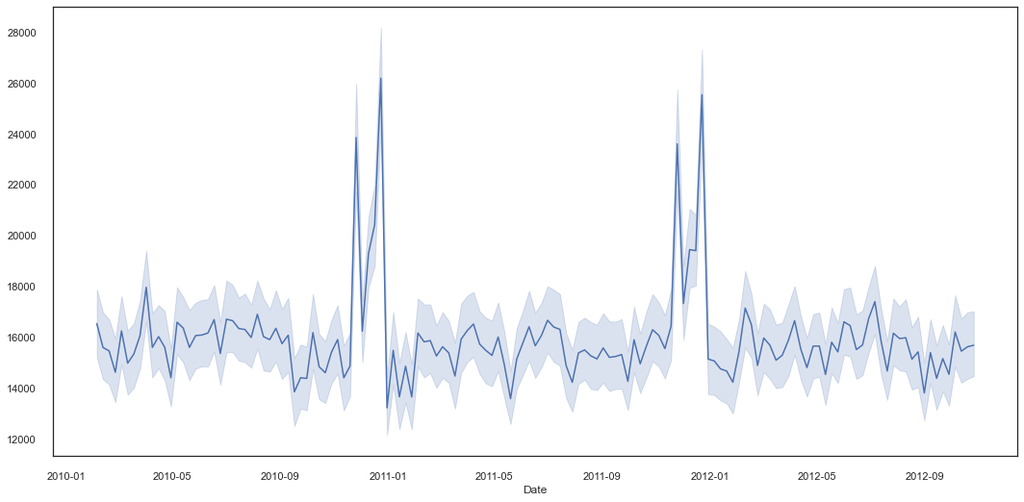

```python
df_p = test.drop(['Date','Weekly_Sales'], axis=1)
y_pred = model.predict(df_p)

plt.figure(figsize=(16,8))
sns.lineplot(test['Date'], y_pred)
```

1. Decision Tree

```python
model = DecisionTreeRegressor(max_depth=15,random_state=42)
model.fit(X_train, y_train)

cv_score = cross_val_score(estimator=model,X=X_train,y=y_train, cv=10)

y_train_pred = model.predict(X_train)
y_test_pred = model.predict(X_test)

r2_test_score = r2_score(y_test,y_test_pred)
mse = np.sqrt(mean_squared_error(y_test,y_test_pred))

print("Cross Validation Score : ", cv_score.mean())
print("r2_score : ", r2_test_score)
print("MSE : ", mse)

accs.append(('Decision Tree',cv_score.mean(),r2_test_score,mse))
```

```
Cross Validation Score :  0.9461582150819925
r2_score :  0.9506108185512976
MSE :  4959.460926246437
```

1. RandomForest

```python
model = RandomForestRegressor(n_estimators=150, random_state=42,criterion='mse')

model.fit(X_train, y_train)

cv_score = cross_val_score(estimator=model,X=X_train,y=y_train, cv=10)

y_train_pred = model.predict(X_train)
y_test_pred = model.predict(X_test)

r2_test_score = r2_score(y_test,y_test_pred)
mse = np.sqrt(mean_squared_error(y_test,y_test_pred))

print("Cross Validation Score : ", cv_score.mean())
print("r2_score : ", r2_test_score)
print("MSE : ", mse)

accs.append(('RandomForest',cv_score.mean(),r2_test_score,mse))
```

```
Cross Validation Score :  0.9742226610005016
r2_score :  0.9768367048370505
MSE :  3396.3991959136342
```

```python
accs
```

```
[('Linear Regression',
  0.08971182881685373,
  0.0890163721698578,
  21299.717564265426),
 ('PolyFeature Regression',
  0.08971182881685373,
  0.21654763954895384,
  19752.626665534302),
 ('Lasso Regression',
  0.21676603096674257,
  0.21645699791341533,
  19753.769274003607),
 ('Ridge Regression',
  0.21696643901217674,
  0.21663777217715674,
  19751.490407955946),
 ('Boosting', 0.9355388957419205, 0.9380677465882397, 5553.630735054828),
 ('Decision Tree', 0.9461582150819925, 0.9506108185512976, 4959.460926246437),
 ('RandomForest', 0.9742226610005016, 0.9768367048370505, 3396.3991959136342)]
```

```python
df_result = pd.DataFrame(data=accs,columns=['model','cv_score','r2_score','mse'])
df_result
```

|  | model | cv_score | r2_score | mse |
| --- | --- | --- | --- | --- |
| 0 | Linear Regression | 0.089712 | 0.089016 | 21299.717564 |
| 1 | PolyFeature Regression | 0.089712 | 0.216548 | 19752.626666 |
| 2 | Lasso Regression | 0.216766 | 0.216457 | 19753.769274 |
| 3 | Ridge Regression | 0.216966 | 0.216638 | 19751.490408 |
| 4 | Boosting | 0.935539 | 0.938068 | 5553.630735 |
| 5 | Decision Tree | 0.946158 | 0.950611 | 4959.460926 |
| 6 | RandomForest | 0.974223 | 0.976837 | 3396.399196 |

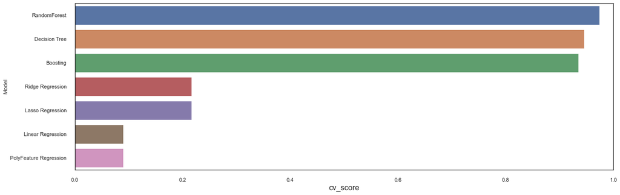

```python
f, axe = plt.subplots(1,1, figsize=(18,6))

df_result.sort_values(by=['cv_score'], ascending=False, inplace=True)

sns.barplot(x='cv_score', y='model', data = df_result, ax = axe)
#axes[0].set(xlabel='Region', ylabel='Charges')
axe.set_xlabel('cv_score', size=16)
axe.set_ylabel('Model')
axe.set_xlim(0,1.0)
plt.show()
```